# Statistical Analysis of Equilibrium Prices

```
# Setup
import os
import sys
sys.path.insert(0, '')
os.chdir("/home/denizalp/Documents/Github/market_models")
import fisherMarket as fm
import numpy as np
import matplotlib.pyplot as plt
```

We will now treat the fisher market’s outcome as a statistical estimator. That is, we would like to understand how does the point estiamtor returned by the convex program for the fisher market perform compared to best statistical estimators.

# Linear Fisher Market

By the KKT conditions, in the linear fisher market the output prices are given by:
$$\begin{align}
p_j = b_i \frac{v_{ij}}{\sum_{j\in [m]}X_{ij} v_{ij}}
\end{align}$$
We want to analyze the distribution of this quantity assuming a distribution of the values of the buyers. In this model, we assume that there is a true market prices vector $\boldsymbol{p}^*$ and that each buyer’s valuation $v_{ij}$ comes from a gamma distribution that is:

$$\begin{align}
\forall i \in [n], & \boldsymbol{v}_{ij} \sim \text{Gamma}(1, p^*_j)
\end{align}$$

where $\boldsymbol{v}_{ij}$ is the valuation vector for the $i^{th}$ buyer.

We will try to compare the statistical estimate returned by the fisher linear convex program to the best estimator for $\forall j \in [m], \ p_j^*$. First, let’s derive such an estimator. Note that the mean of the $v_{ij}'s$ is:
$$\begin{align}
\mathbb{E}[v_{ij}] = p^*_j
\end{align}$$

The best estimator for the mean of the distribution is the sample mean as a result, we will compare the fisher linear market prices to:

$$\begin{align}
\forall j \in [m], \ \ \mu_j = \frac{\sum_{i \in [n]} v_{ij}}{n}
\end{align}$$

We declare the following environment:

```
# Number of bettors
n = 5

# Number of horses
m = 3

# Budgets
budgets = np.array([0.2, 0.2, 0.2, 0.2, 0.2])

# True track probabilities
true_v = np.array([0.3, 0.2, 0.5])
```

```
fisher_prices = []
means = []

for i in range(1000):
    # Sample Valuations
    V = np.array([np.random.gamma(1, v, size =n) for v in true_v]).T

    # Store mean of valuations
    means.append(np.mean(V, axis = 0))

    # Find estimates given by fisher market
    market = fm.FisherMarket(V, budgets)
    X, p =  market.solveMarket("linear", printResults = False)
    fisher_prices.append(p) # Store fisher prices
fisher_prices = np.array(fisher_prices)
means = np.array(means)
```

We first plot the histogram of fisher prices and the true price.

```
# Plotting Fisher prices
fig, axs = plt.subplots(1, 3, sharey=True, tight_layout=True)

for i in range(3):
    axs[i].hist(fisher_prices[:,i], bins = 20, alpha = 0.7, label = "Estimated Prices")
    axs[i].axvline(x = true_v[i], color = "red", label = "True Mean")
    axs[i].axvline(x = np.mean(fisher_prices[:,i]), color = "Green", label = "Mean of Price Estimates")
axs[1].set_xlabel("Price")
axs[0].set_ylabel("Frequency")
plt.legend(bbox_to_anchor=(1.05, 1), fontsize=7, loc='lower center')
plt.show()
```

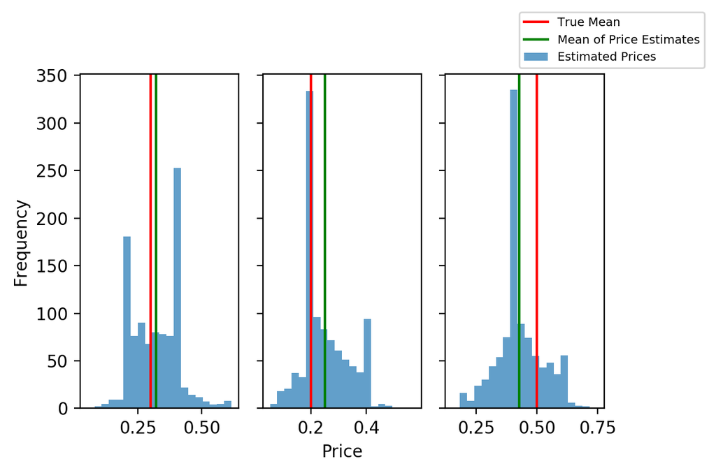

We then plot the histogram of the mean valuations:

```
# Plotting Fisher prices
fig, axs = plt.subplots(1, 3, sharey=True, tight_layout=True)

for i in range(3):
    axs[i].hist(means[:,i], bins = 20, alpha = 0.8, label = "Estimated Prices")
    axs[i].axvline(x = true_v[i], color = "red", label = "True Mean")
    axs[i].axvline(x = np.mean(means[:,i]), color = "Green", label = "Mean of Price Estimates")

axs[1].set_xlabel("Price")
axs[0].set_ylabel("Frequency")
plt.legend(bbox_to_anchor=(1.05, 1), fontsize=7, loc='lower center')
plt.show()
```

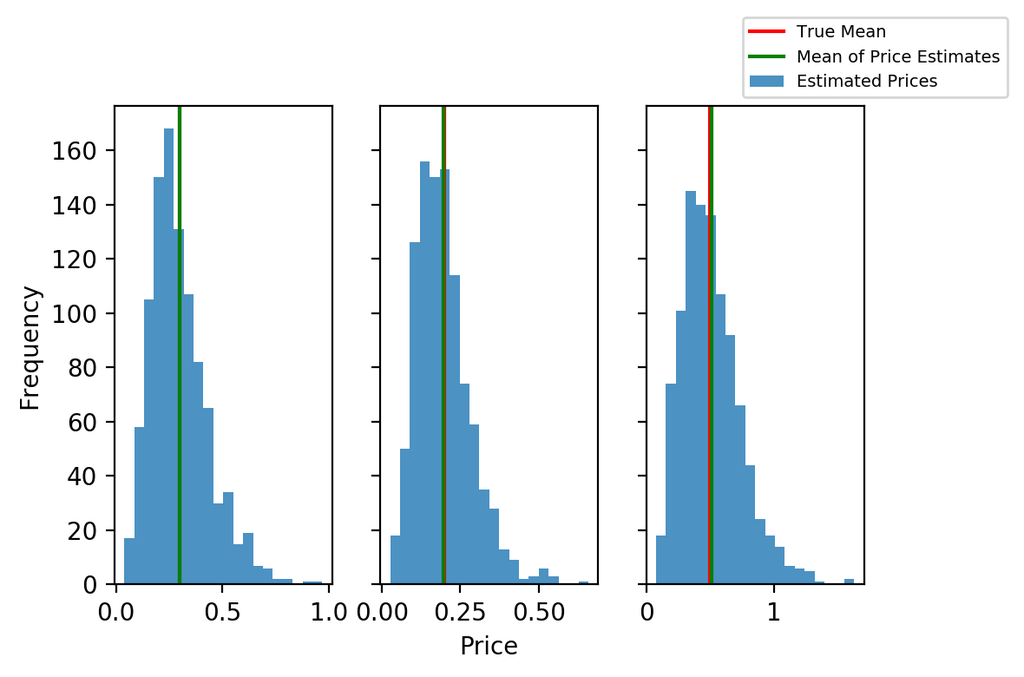

# Quasi-linear Fisher

```
# Number of bettors
n = 5

# Number of horses
m = 3

# Budgets
budgets = np.array([0.2, 0.2, 0.2, 0.2, 0.2])

# True track probabilities
true_v = np.array([0.3, 0.2, 0.5])
```

```
fisher_prices = []
means = []

for i in range(1000):
    # Sample Valuations
    V = np.array([np.random.gamma(1, v, size =n) for v in true_v]).T

    # Store mean of valuations
    means.append(np.mean(V, axis = 0))

    # Find estimates given by fisher market
    market = fm.FisherMarket(V, budgets)
    X, p =  market.solveMarket("quasi-linear", printResults = False)
    fisher_prices.append(p) # Store fisher prices
fisher_prices = np.array(fisher_prices)
means = np.array(means)
```

We first plot the histogram of fisher prices and the true price.

```
# Plotting Fisher prices
fig, axs = plt.subplots(1, 3, sharey=True, tight_layout=True)

for i in range(3):
    axs[i].hist(fisher_prices[:,i], bins = 20, alpha = 0.7, label = "Estimated Prices")
    axs[i].axvline(x = true_v[i], color = "red", label = "True Mean")
    axs[i].axvline(x = np.mean(fisher_prices[:,i]), color = "Green", label = "Mean of Price Estimates")
axs[1].set_xlabel("Price")
axs[0].set_ylabel("Frequency")
plt.legend(bbox_to_anchor=(1.05, 1), fontsize=7, loc='lower center')
plt.show()
```

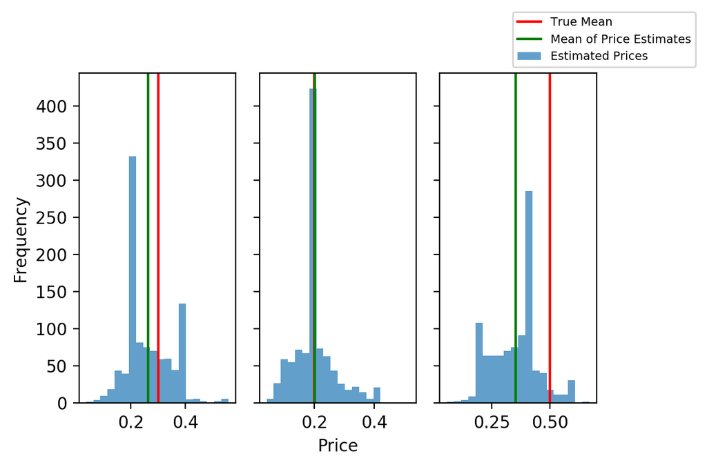

We then plot the histogram of the mean valuations:

```
# Plotting Fisher prices
fig, axs = plt.subplots(1, 3, sharey=True, tight_layout=True)

for i in range(3):
    axs[i].hist(means[:,i], bins = 20, alpha = 0.8, label = "Estimated Prices")
    axs[i].axvline(x = true_v[i], color = "red", label = "True Mean")
    axs[i].axvline(x = np.mean(means[:,i]), color = "Green", label = "Mean of Price Estimates")

axs[1].set_xlabel("Price")
axs[0].set_ylabel("Frequency")
plt.legend(bbox_to_anchor=(1.05, 1), fontsize=7, loc='lower center')
plt.show()
```

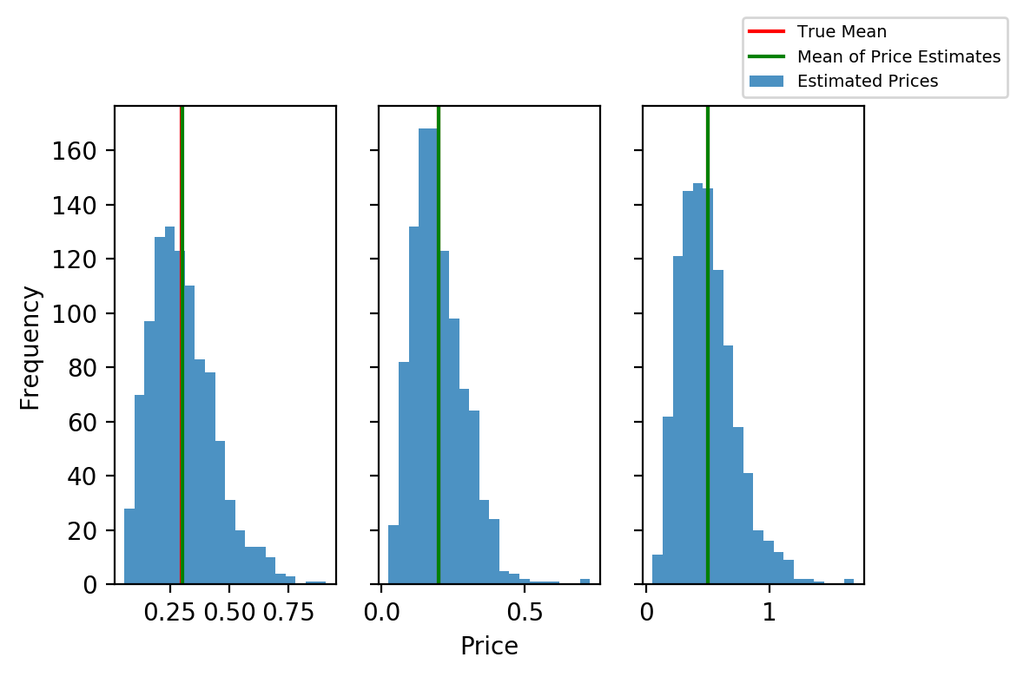

Published from stat_analysis.pmd using [Pweave](http://mpastell.com/pweave) 0.30.3 on 19-03-2020.